# Final Assignment Analysis of Spatiotemporal Data

Spatial point pattern analysis of wind turbines in the precincts of NRW

Alexander Pilz

2023-03-08

## Introduction

In July 2022, the German government formulated the “Act to Increase and Accelerate the Expansion of Onshore Wind Energy Facilities” which underscores the goal of increasing the use of renewable energy sources in Germany. The law stipulates that 1.8% of the area of the federal state of North Rhine-Westphalia (NRW) must be used for power generation from wind energy [8]. The power yields of such facilities are depended on a multitude of factors. It could be argued that wind turbines should build where their potential energy yields are the highest. The planning and execution of construction efforts is the task of multiple administrative units. The federal state (Land NRW) and precincts (Bezirke) identify and disclose areas which are to be used for the power generation by means of wind energy in the federal state development plan (Landesentwicklungsplan) and the derivative regional plans (Regionalpläne). Some of the planning steps involved are subject to personal considerations. The counties (Kreise) are only responsible for the planning and subsequent construction of the actual wind parks. Thus the point pattern analysis is conducted on precinct level [9][10]. Instead of concerning itself with future planning practices the following point pattern analysis, conducted during the seminar Analysis of spatiotemporal data in 2022/23, tries to find and describe a possible relationship between the point pattern formed by existing wind turbines in NRW and the environmental Variable of the specific energy power density. Results such studies could be used to identify shortcomings of decision making processes and might be helpful for their optimization. In the first part of this analysis is used to conduct a preliminary examination of the datasets used. The mandatory test for Complete spatial randomness is also part of this preliminary examination. The second part tries to establish a possible correlation between the local wind turbine intensities using the SEPD as a tessellated surface and the values of the SEPD. The third part attempts to model the wind turbine point process using the SEPD as a covariate.

## Data

The datasets employed during this point pattern analysis are all available openly and free of charge at the GEOportal.NRW. The employed coordinate reference system of all datasets is ETRS89 / UTM zone 32N commonly used for official and cadastral data in NRW. The analysis itself was carried out using the programming language R and the packages sf, raster, spatstat, plyr, maptools, ggplot2 and their dependencies.

```r
#import libraries
library(sf)
library(raster)
library(spatstat)
library(plyr)
library(maptools)
library(ggplot2)

#set working directory
setwd(getwd())
```

The dataset containing polygonal features of the precincts of the federal state of NRW, lists five precincts namely Arnsberg, Detmold, Köln, Düsseldorf and Münster (see figure 1).

```r
#import precincts
precincts <- st_read("data/dvg2_EPSG25832_Shape/dvg2rbz_nw.shp")
#union precincts
precinctsUnion <- st_union(precincts)
```

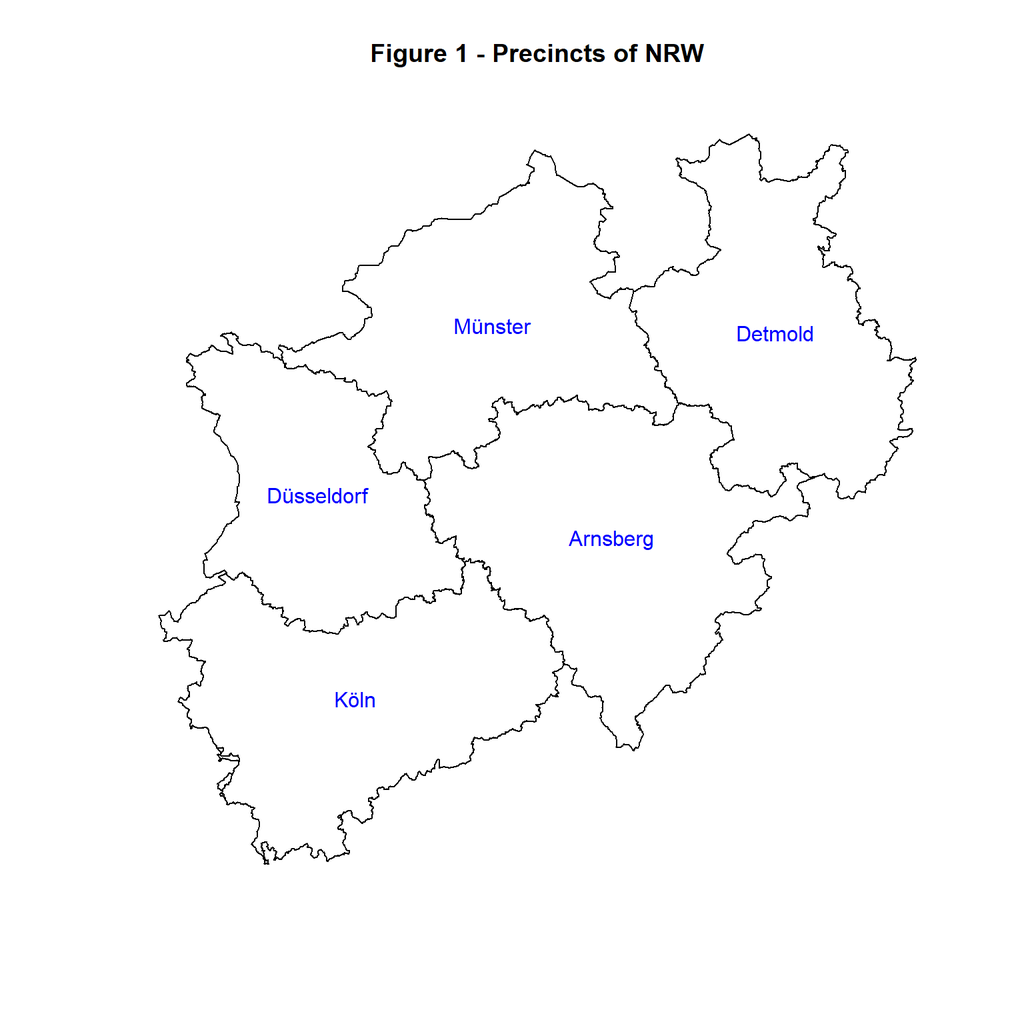

The point pattern to be examined represents the existing wind turbines in NRW. The Shapefile contains 3797 point features with 12 attribute fields which contain information about the wind turbine like the diameter of its rotor, the year of its commissioning and the administrative unit in which they are situated (see figure 2).

```r
#import wind turbines
windTurbines <- st_read("data/OpenEE-Windenergie_EPSG25832_Shape/Windbetrieb_Standorte.shp")
```

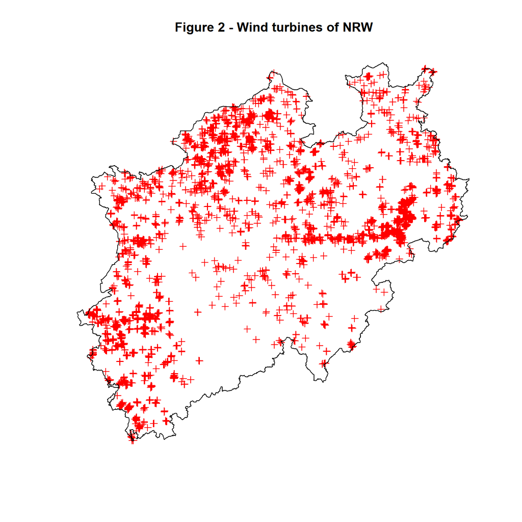

```r
#import potential yields
potentialYields <- raster("data/Energieleistungsdichte-100m_EPSG25832_TIFF/en_100m_klas.tif")
#create vector of yields
yields <- c("1", "2", "3", "4", "5", "6", "7")
```

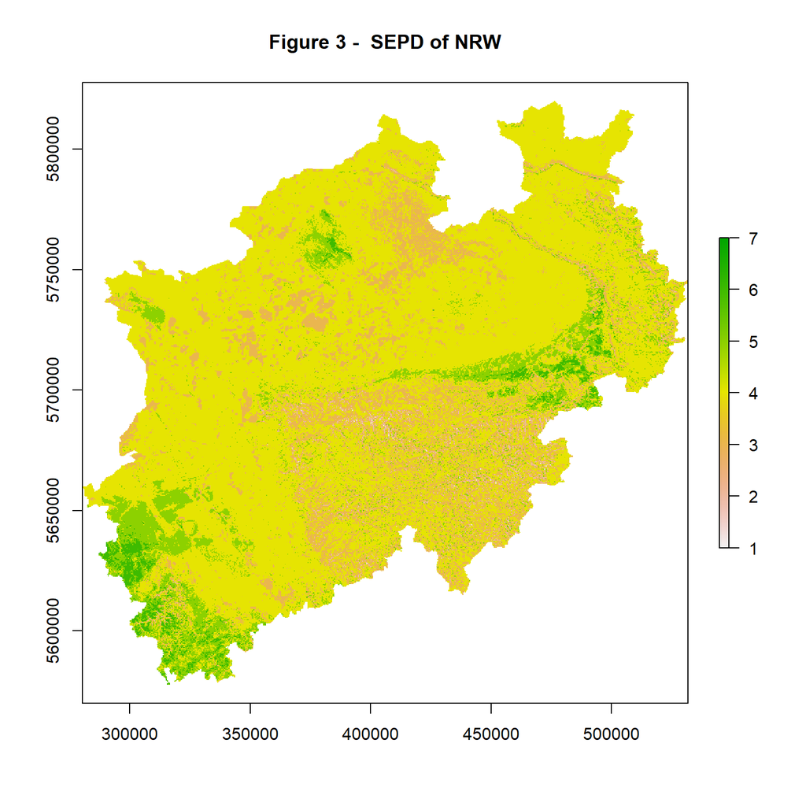

## Methods

### Part I - Preliminary analysis

In order to get an overview of the data the wind turbine counts and global intensities for each precinct are computed and visualized. When computing the global intensities from the wind turbine point pattern, the smoothing kernel bandwidth $sigma$ is chosen using a method described in [6]. Also Jones-Diggle improved edge corrections are applied. Before analyzing the point pattern formed by the wind turbines in the precincts of NRW some preliminary tests are performed. These encompass tests for complete spatial randomness. The rejection of this is according to [3] “is a minimal prerequisite to any serious attempt to model an observed pattern” [3]. Therefore the empirical functions are compared to a theoretical function which corresponds to a homogeneous poisson point process which is conforms to complete spatial randomness [2].

**Hypotheses Part I:**  
$H_{0} - I$: The wind turbines of NRW are distributed independently at random and uniformly in each precinct.

$Ha_{1} - I$: The wind turbines of NRW exhibit a regular pattern and are not distributed independently at random and uniformly in each precinct.

$Ha_{2} - I$: The wind turbines of NRW exhibit a clustered pattern and are not distributed independently at random and uniformly in each precinct.

To confirm or reject these hypotheses the $G$-, $F$-, and $J$-functions were applied. When computing the $G$-, $F$-, and $J$-functions the best edge correction method is chosen automatically. The Monte-Carlo envelopes are computed simulating 99 point processes. The $G$-function, also called the nearest-neighbour distance distribution function [2], “measures the distribution of the distances from an arbitrary event to its nearest event” [4]. In order assess the compatibility of the wind turbine point pattern with complete spatial randomness the empirical function $\hat{G}_{obs}$ is plotted against the theoretical function $(r)G_{theo}(r)$, thus the expectation under complete spatial randomness, and its Monte Carlo envelope indicated by $\hat{G}_{hi}(r)$ and $\hat{G}_{lo}(r)$ [4] for each precinct. Complete spatial randomness would be accepted for a given point process if the $\hat{G}_{obs}(r)$ function runs close to the $G_{theo}(r)$ function or within its Monte Carlo envelope. A clustered pattern would be indicated if the empirical function $\hat{G}_{obs}(r)$ runs above the $G_{theo}(r)$ and its Monte Carlo envelope. Similarly a $\hat{G}_{obs}(r)$ function which runs below the $G_{theo}(r)$ and its Monte Carlo envelope would indicate a regular pattern [2][4].

The $F$-function, also called the empty-space function [2], “measures the distribution of all distances from an arbitrary point of the plane to its nearest event” [4]. Assessment of its results is done in a similar way as with the G-function by plotting empirical function $\hat{F}_{obs}(r)$ against the theoretical function $F_{theo}(r)$ and its Monte Carlo envelope indicated by $\hat{F}_{hi}(r)$ and $\hat{F}_{lo}(r)$ [4]. One would accept complete spatial randomness for the $F$-function under the same conditions as for the $G$-function. Regarding the indication of regular or clustered patterns, the reverse conditions as with the $G$-function must be applied [2][4].

The $J$-function is a combination of the $G$- and $F$-functions [2]. Assessment is again done by plotting the empirical function $\hat{J}_{obs}(r)$ against the theoretical function $J_{theo}(r)$ and its Monte Carlo envelope indicated by $\hat{J}_{hi}(r)$ and $\hat{J}_{lo}(r)$. The interpretation of the $J$-function can be more complex than with the $G$- and $F$-functions since it can also be used for “characterizing the interaction of points in terms of its type, strength and range”. Clustered and regular patters are nonetheless indicated by the $J$-function as well where values below 1 would indicate the former and values above 1 the latter [1].

```r
#create subset of wind turbines for each precinct
windTurbinesArnsberg <- st_intersection(windTurbines, precincts[precincts$GN == "Arnsberg",])
windTurbinesDetmold <- st_intersection(windTurbines, precincts[precincts$GN == "Detmold",])
windTurbinesKöln <- st_intersection(windTurbines, precincts[precincts$GN == "Köln",])
windTurbinesDüsseldorf <- st_intersection(windTurbines, precincts[precincts$GN == "Düsseldorf",])
windTurbinesMünster <- st_intersection(windTurbines, precincts[precincts$GN == "Münster",])

#create planar point patterns from wind turbine subsets using precincts as observation windows
pppArnsberg <- as.ppp(c(st_geometry(precincts[precincts$GN == "Arnsberg",]), st_geometry(windTurbinesArnsberg)))
pppDetmold <- as.ppp(c(st_geometry(precincts[precincts$GN == "Detmold",]), st_geometry(windTurbinesDetmold)))
pppKöln <- as.ppp(c(st_geometry(precincts[precincts$GN == "Köln",]), st_geometry(windTurbinesKöln)))
pppDüsseldorf <- as.ppp(c(st_geometry(precincts[precincts$GN == "Düsseldorf",]), st_geometry(windTurbinesDüsseldorf)))
pppMünster <- as.ppp(c(st_geometry(precincts[precincts$GN == "Münster",]), st_geometry(windTurbinesMünster)))

#create vector of precinct names and wind turbine counts
precintNames <- c("Arnsberg", "Detmold", "Köln", "Düsseldorf", "Münster")
windTurbineCounts <- c(pppArnsberg$n, pppDetmold$n, pppKöln$n, pppDüsseldorf$n, pppMünster$n)

#compute wind turbine density for each precinct
windTurbineDensities <- c(pppArnsberg$n/(as.numeric(st_area(precincts[precincts$GN == "Arnsberg",]))/1000000),
                          pppDetmold$n/(as.numeric(st_area(precincts[precincts$GN == "Detmold",]))/1000000),
                          pppKöln$n/(as.numeric(st_area(precincts[precincts$GN == "Köln",]))/1000000),
                          pppDüsseldorf$n/(as.numeric(st_area(precincts[precincts$GN == "Düsseldorf",]))/1000000),
                          pppMünster$n/(as.numeric(st_area(precincts[precincts$GN == "Münster",]))/1000000))

#compute precinct areas in km²
precintAreas <- c(as.numeric(st_area(precincts[precincts$GN == "Arnsberg",]))/1000000,
                  as.numeric(st_area(precincts[precincts$GN == "Detmold",]))/1000000,
                  as.numeric(st_area(precincts[precincts$GN == "Köln",]))/1000000,
                  as.numeric(st_area(precincts[precincts$GN == "Düsseldorf",]))/1000000,
                  as.numeric(st_area(precincts[precincts$GN == "Münster",]))/1000000)

#create dataframe with precinct names, areas, wind turbine counts and densities
precinctDf <- data.frame(precintNames, precintAreas, windTurbineCounts, windTurbineDensities)
colnames(precinctDf) <- c('Precinct','Area in km²','Turbine count', 'Turbine density per km²')

#compute densities of wind turbines for each precinct
densityArnsberg <- density(pppArnsberg, sigma = bw.diggle, diggle = TRUE, edge = TRUE)
densityDetmold <- density(pppDetmold, sigma = bw.diggle, diggle = TRUE, edge = TRUE)
densityKöln <- density(pppKöln, sigma = bw.diggle, diggle = TRUE, edge = TRUE)
densityDüsseldorf <- density(pppDüsseldorf, sigma = bw.diggle, diggle = TRUE, edge = TRUE)
densityMünster <- density(pppMünster, sigma = bw.diggle, diggle = TRUE, edge = TRUE)
```

```
##     Precinct Area in km² Turbine count Turbine density per km²
## 1   Arnsberg    8007.106           633              0.07905478
## 2    Detmold    6520.132          1002              0.15367787
## 3       Köln    7362.591           678              0.09208714
## 4 Düsseldorf    5291.773           417              0.07880156
## 5    Münster    6914.908          1067              0.15430429
```

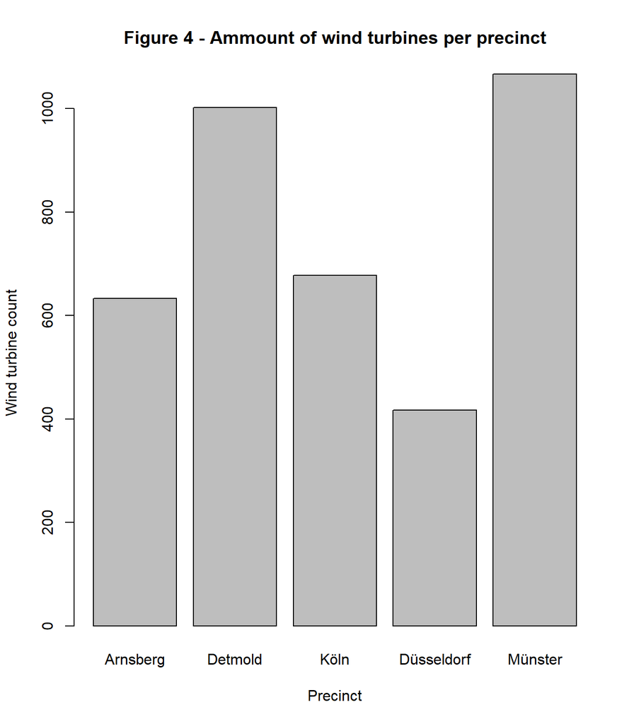

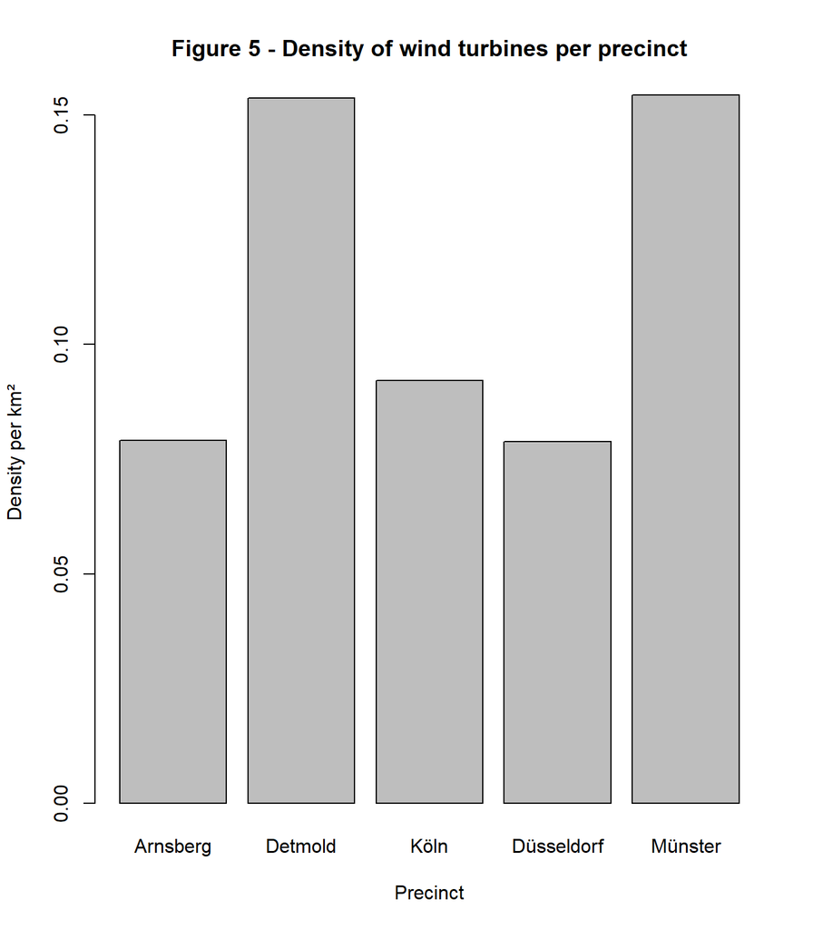

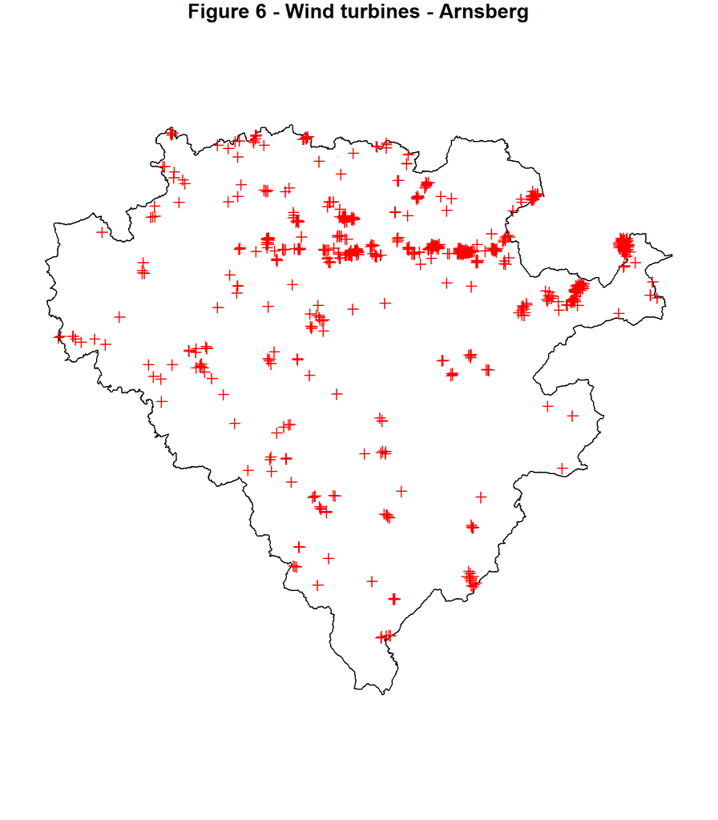

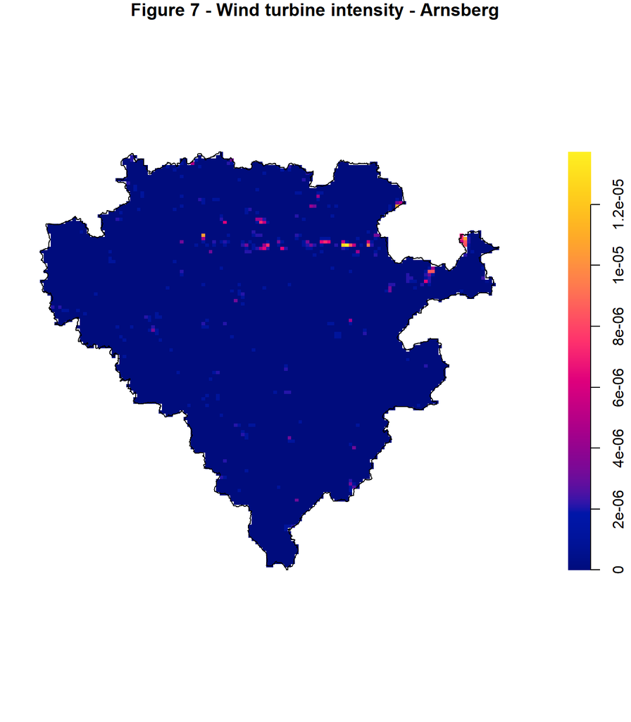

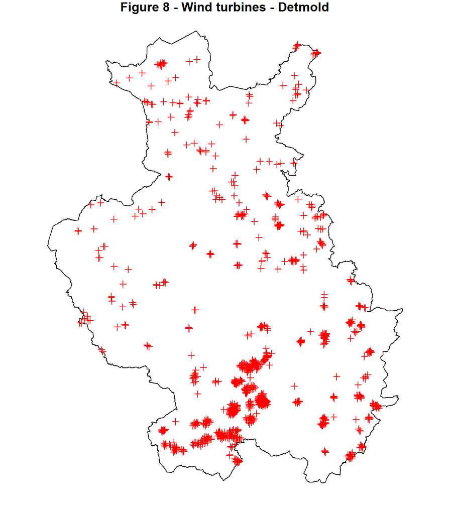

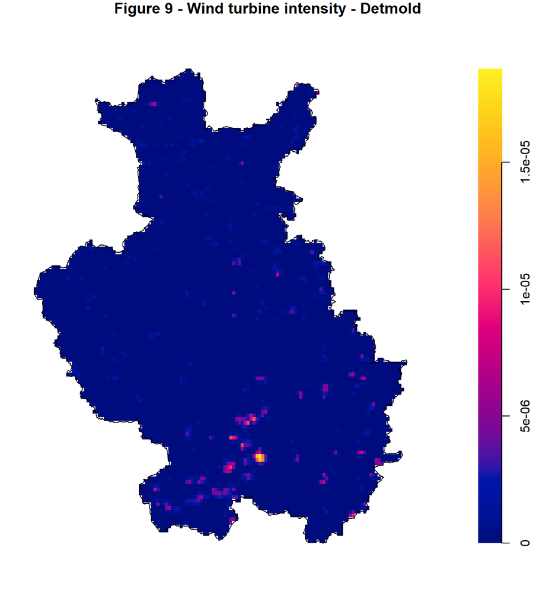

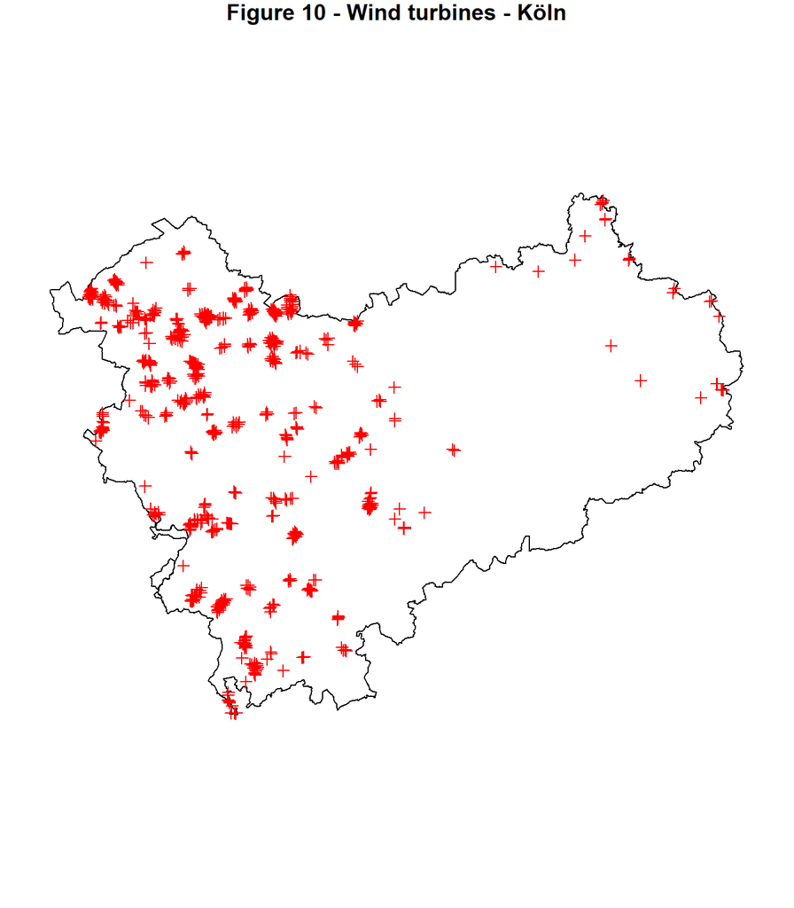

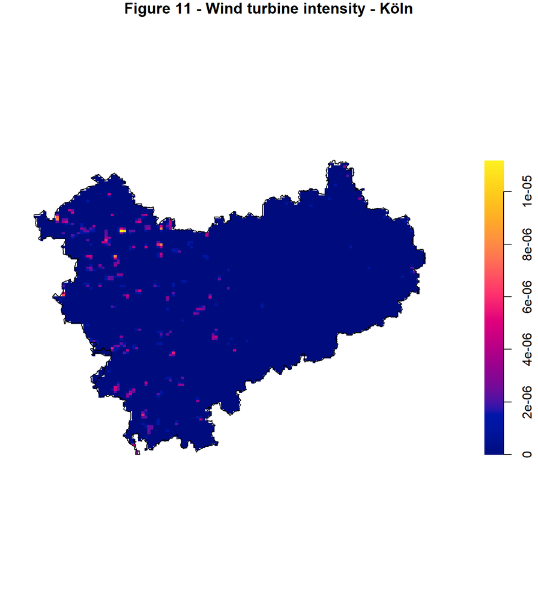

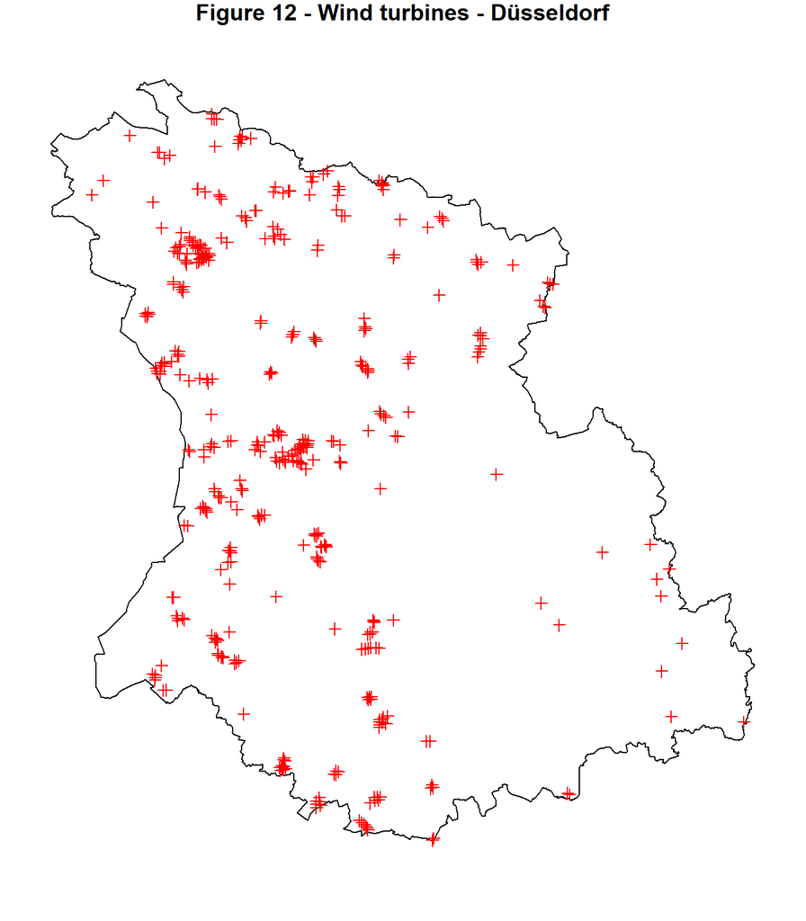

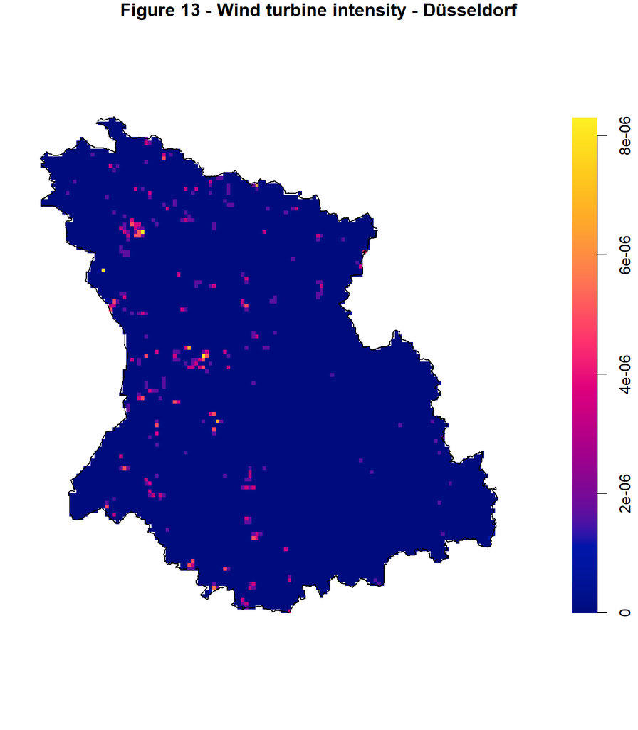

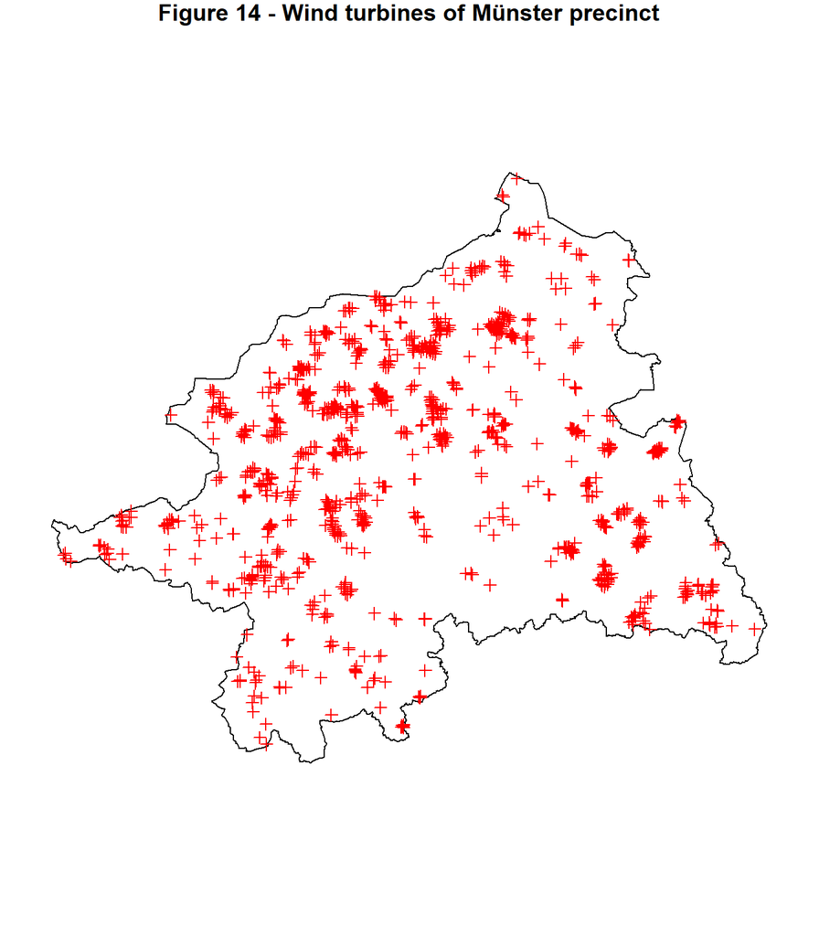

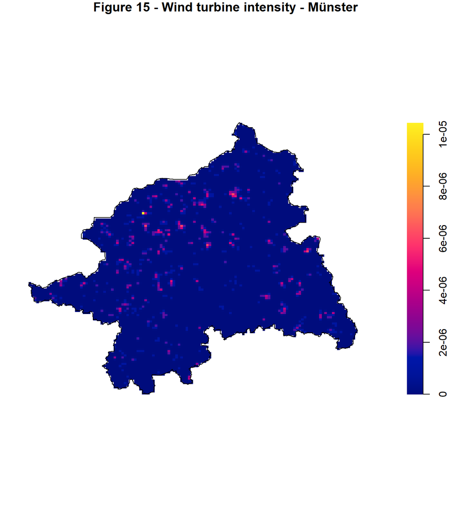

[10 more figures not shown]

[output not shown]

[output not shown]

[output not shown]

[output not shown]

[output not shown]

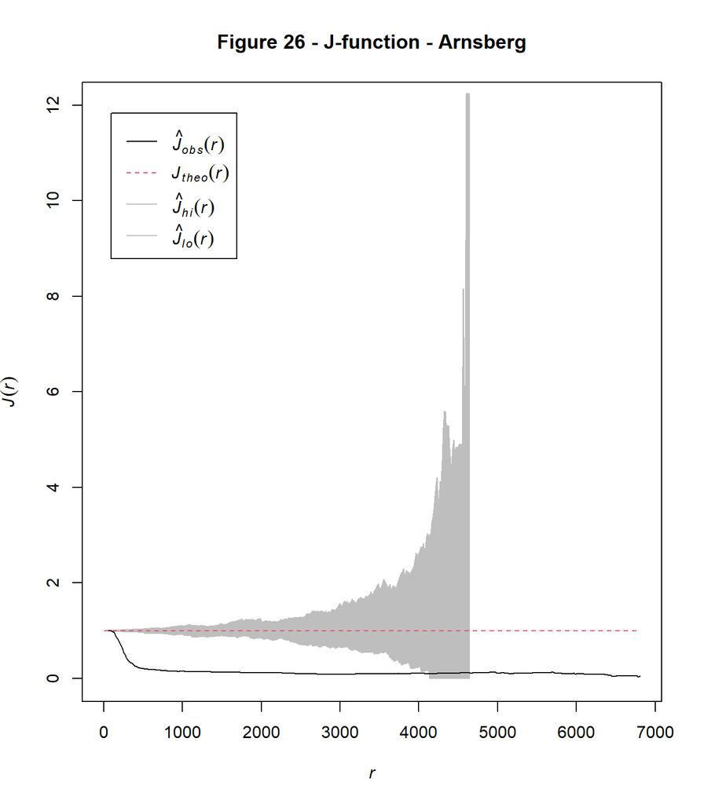

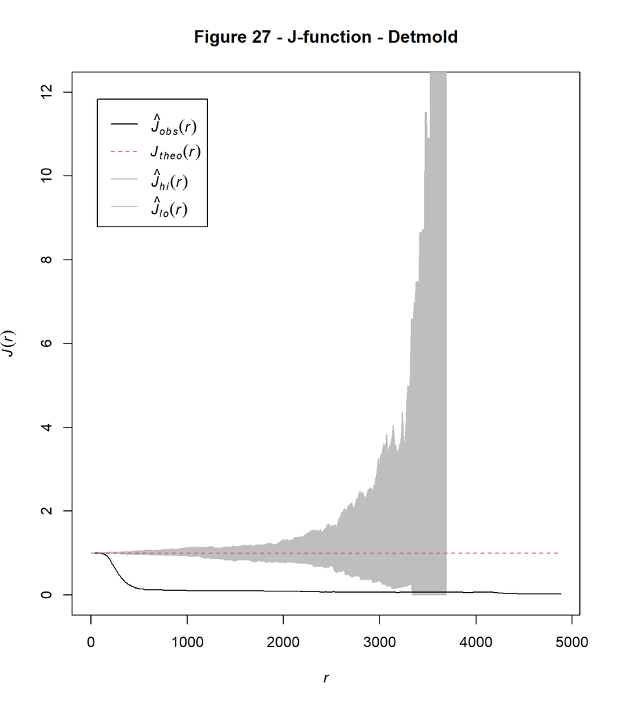

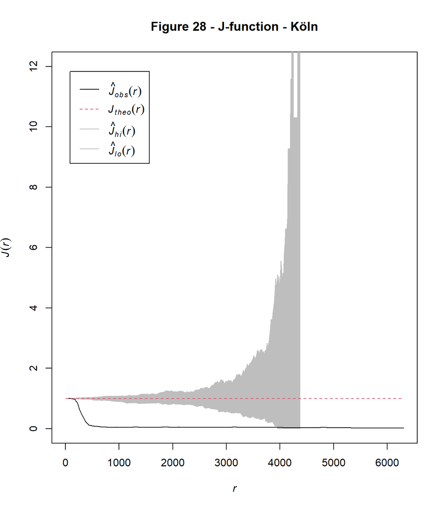

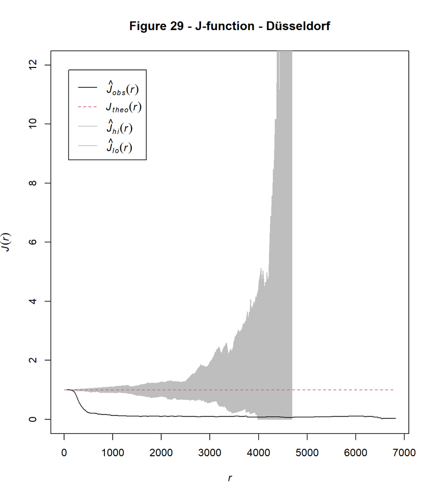

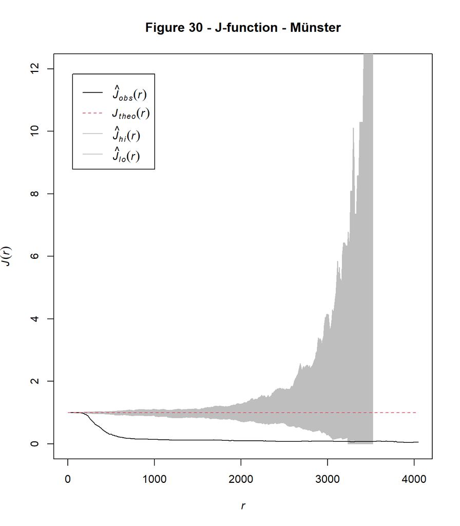

### Part II - Local intentity with tessellated covariat

A firsts step towards finding and understanding a possible relationship between a point pattern and corresponding values of an underlying variable could be a local density analysis using the SEPD as a tessellated covariate. The intensities are computed for the subareas formed by the pixels of equal value. A linear model can also be fitted to the intensities in relation to the covariate. Such an approach can be used if it is believed that the point pattern process is driven by the values of the underlying tessellated surface. Here the assumption is that areas with high potential power yields which are indicated by high SEPD values should exhibit higher wind turbine densities.

**Hypotheses Part II:**  
$H_{0} - II$: There is no linear correlation between local wind turbine densities and the SEPD values.

$Ha_{1} - II$: There is a positive linear correlation between local wind turbine densities and the SEPD values.

$Ha_{2} - II$: There is a negative linear correlation between local wind turbine densities and the SEPD values.

The trend of the linear model can also be fitted to the intensities in relation to the covariate can be used as a first indication for a possible correlation between the two. The Kendall-tau rank correlation is used to compute the correlation coefficients since not all series are normally distributed according to the Shapiro-Wilk test and it tends to be more robust against outliers than the Spearman rank correlation [5]. The local wind turbine intensities are ranked before computing the correlation coefficients. The correlation coefficient ranges form -1 to 1, where a positive value would indicate that high SEPD are accompanied by high wind turbine intensities while a negative value would indicate the opposite. The significance of a correlation can assessed by the accompanying p-value which should be smaller than 0.05.

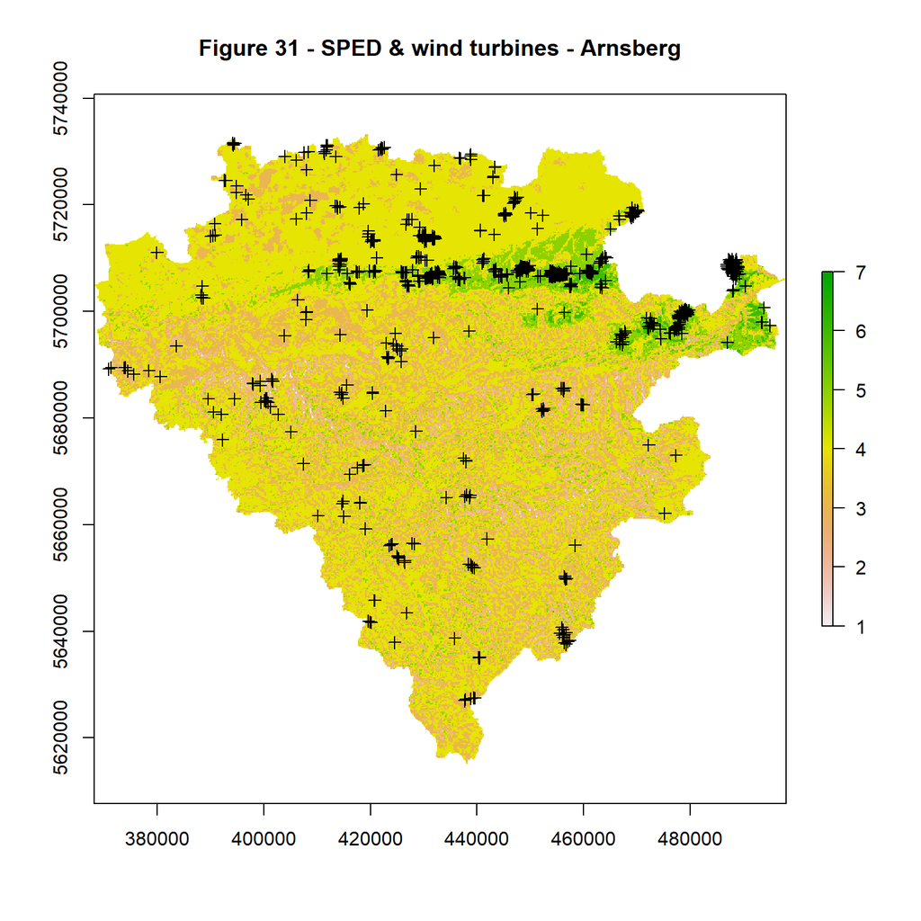

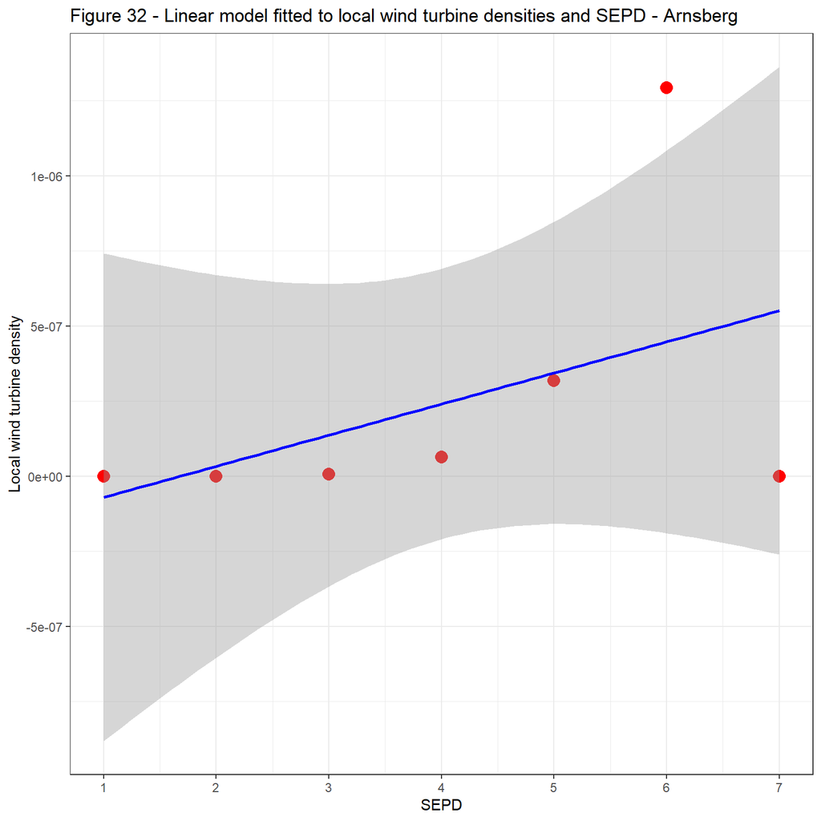

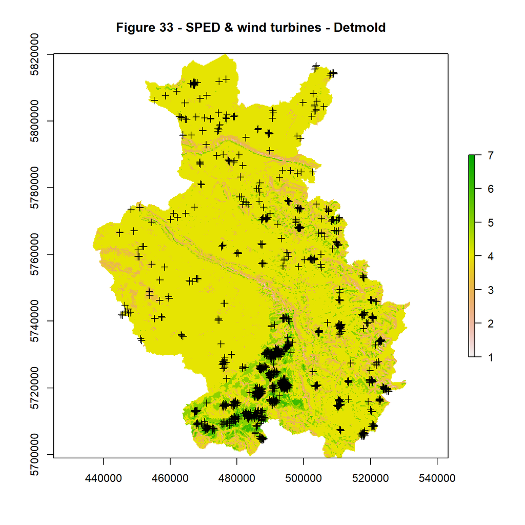

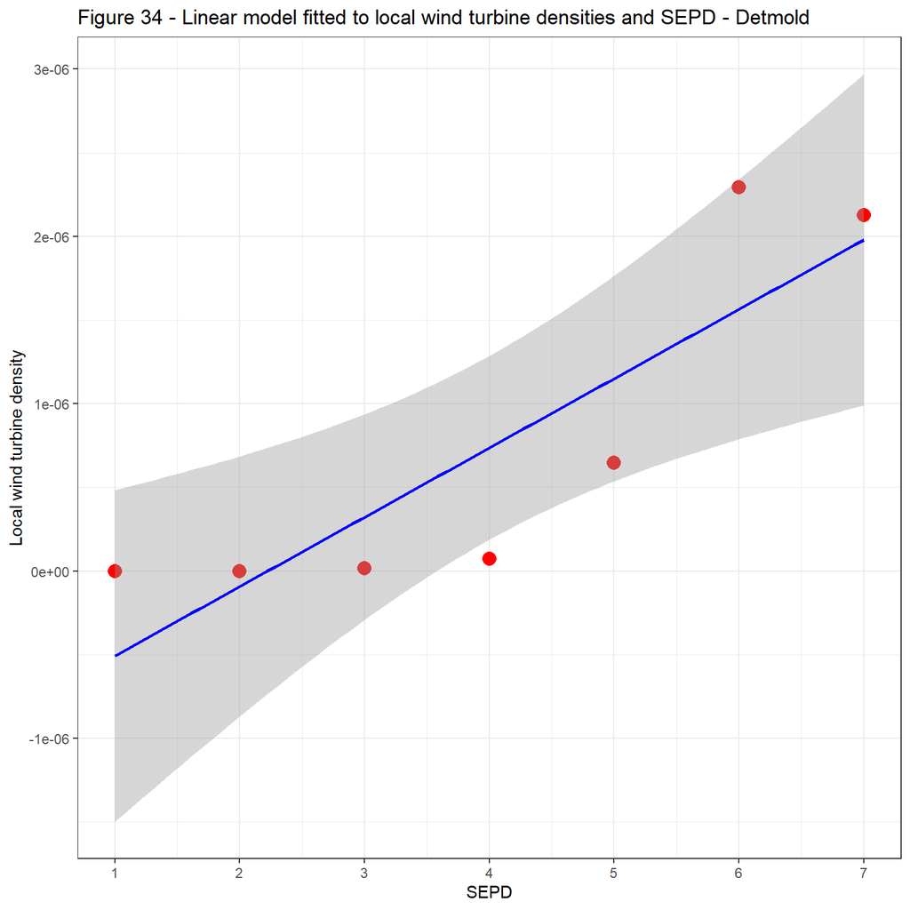

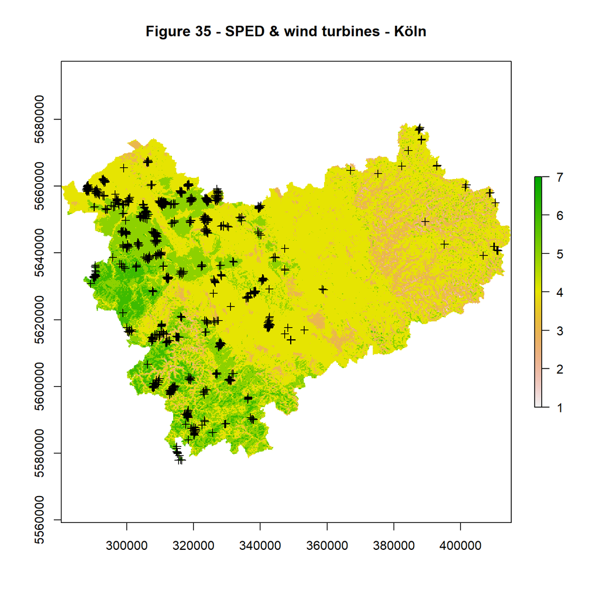

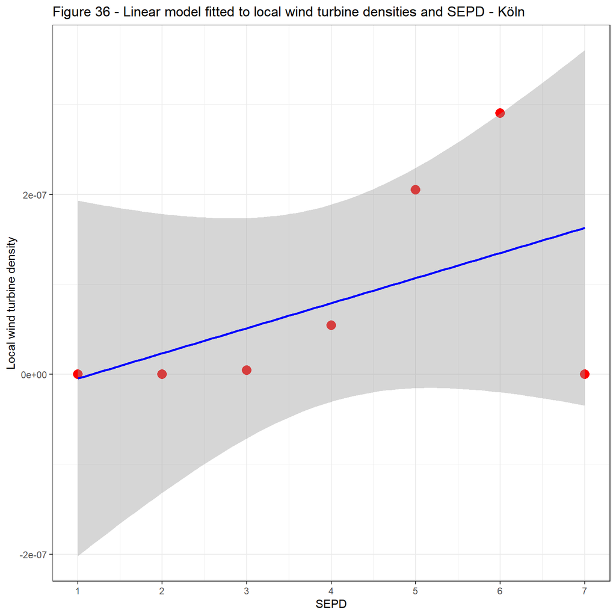

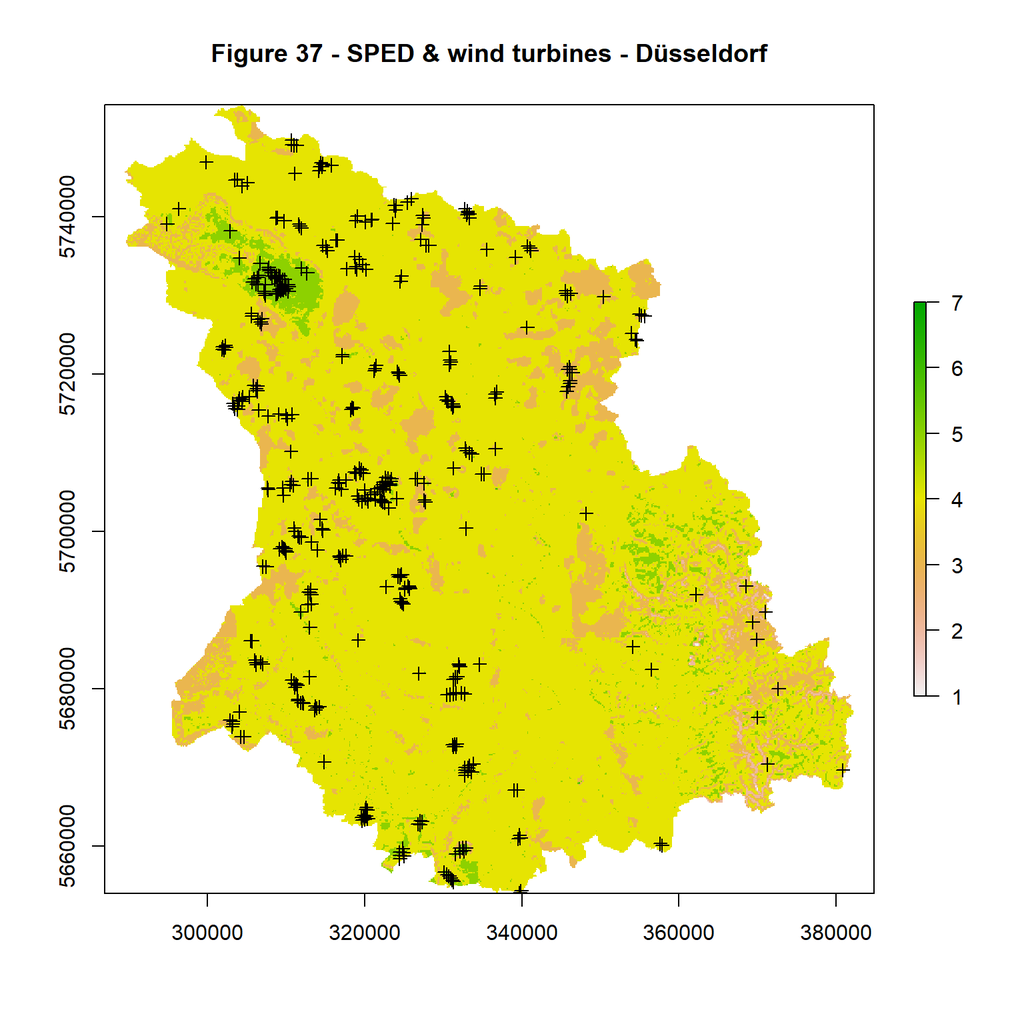

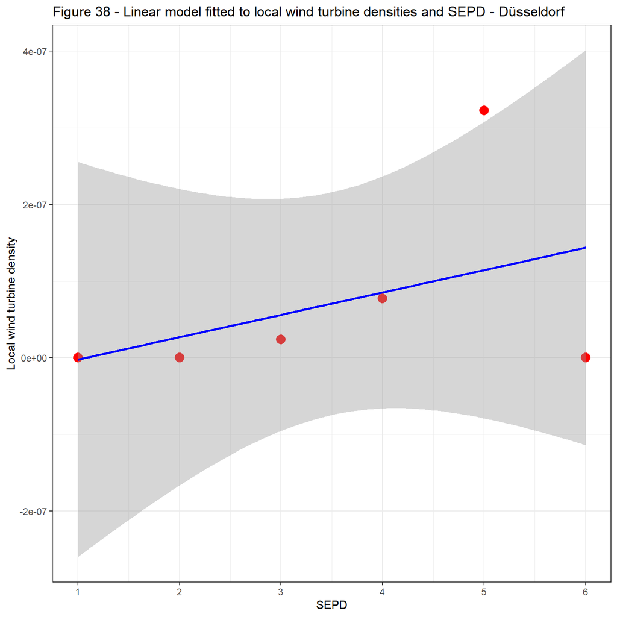

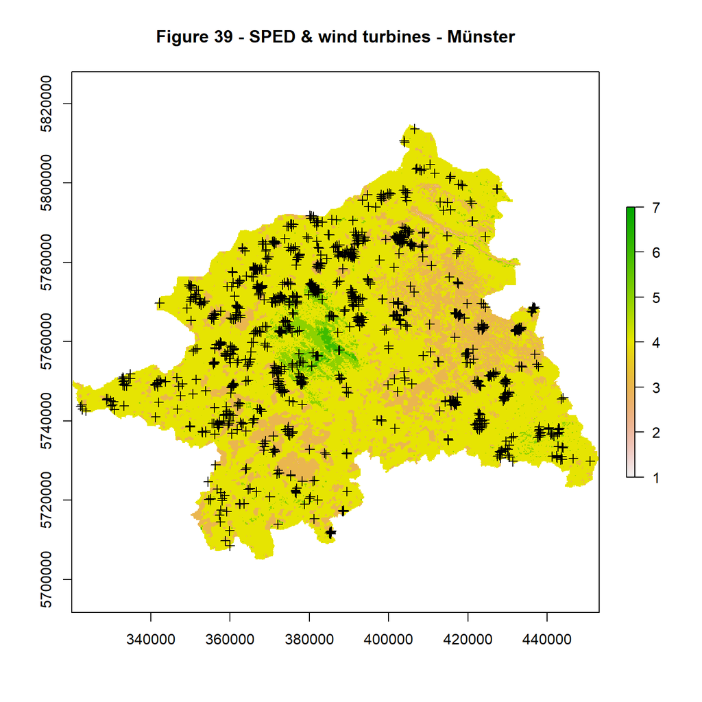

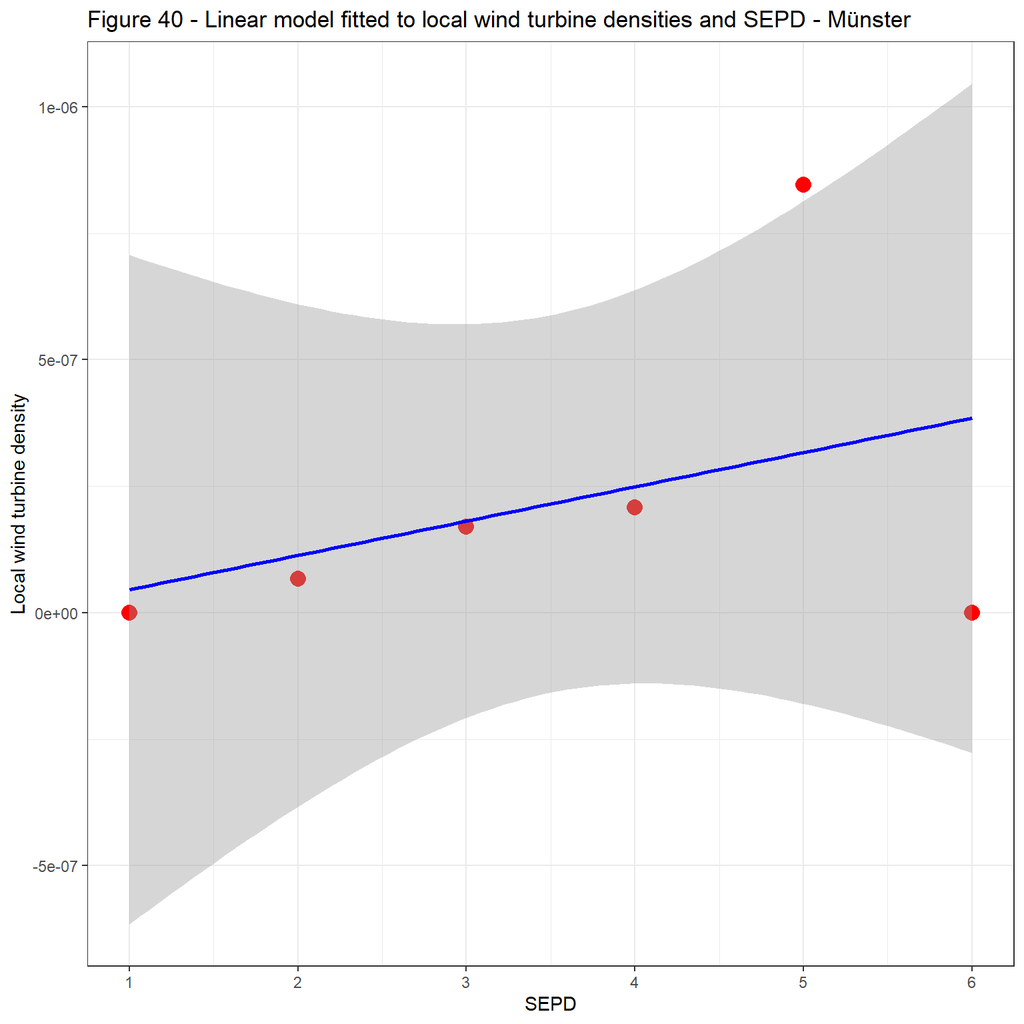

```
##
##  Kendall's rank correlation tau
##
## data:  as.numeric(localDensityArnsberg.df$tile) and localDensityArnsberg.df$densityRank
## z = 1.5681, p-value = 0.1169
## alternative hypothesis: true tau is not equal to 0
## sample estimates:
##       tau
## 0.5143445
```

```
##
##  Kendall's rank correlation tau
##
## data:  as.numeric(localDensityDetmold.df$tile) and localDensityDetmold.df$densityRank
## z = 2.7344, p-value = 0.006249
## alternative hypothesis: true tau is not equal to 0
## sample estimates:
##       tau
## 0.8783101
```

```
##
##  Kendall's rank correlation tau
##
## data:  as.numeric(localDensityKöln.df$tile) and localDensityKöln.df$densityRank
## z = 1.5681, p-value = 0.1169
## alternative hypothesis: true tau is not equal to 0
## sample estimates:
##       tau
## 0.5143445
```

```
##
##  Kendall's rank correlation tau
##
## data:  as.numeric(localDensityDüsseldorf.df$tile) and localDensityDüsseldorf.df$densityRank
## z = 1.2081, p-value = 0.227
## alternative hypothesis: true tau is not equal to 0
## sample estimates:
##       tau
## 0.4472136
```

```
##
##  Kendall's rank correlation tau
##
## data:  as.numeric(localDensityMünster.df$tile) and localDensityMünster.df$densityRank
## z = 1.1476, p-value = 0.2511
## alternative hypothesis: true tau is not equal to 0
## sample estimates:
##       tau
## 0.4140393
```

```r
#create vector of breaks
breaks <- c(1,2,3,4,5,6,7)

#compute local intensity using the  SEPD as tessellated covariate
tessellationArnsberg <- tess(image=potentialYieldsArnsbergMasked)
localDensityArnsberg <- quadratcount(pppArnsberg, tess=tessellationArnsberg)
localDensityArnsberg.dens <- intensity(localDensityArnsberg)

tessellationDetmold <- tess(image=potentialYieldsDetmoldMasked)
localDensityDetmold <- quadratcount(pppDetmold, tess=tessellationDetmold)
localDensityDetmold.dens <- intensity(localDensityDetmold)

tessellationKöln <- tess(image=potentialYieldsKölnMasked)
localDensityKöln <- quadratcount(pppKöln, tess=tessellationKöln)
localDensityKöln.dens <- intensity(localDensityKöln)

tessellationDüsseldorf <- tess(image=potentialYieldsDüsseldorfMasked)
localDensityDüsseldorf <- quadratcount(pppDüsseldorf, tess=tessellationDüsseldorf)
localDensityDüsseldorf.dens <- intensity(localDensityDüsseldorf)

tessellationMünster <- tess(image=potentialYieldsMünsterMasked)
localDensityMünster <- quadratcount(pppMünster, tess=tessellationMünster)
localDensityMünster.dens <- intensity(localDensityMünster)

#compute correlation between  SEPD and (ranked) wind turbine intensity
localDensityArnsberg.df <- data.frame(localDensityArnsberg.dens)
localDensityArnsberg.df$densityRank <- rank(localDensityArnsberg.df$Freq, ties.method= "max")
localDensityArnsberg.cor <-cor.test(as.numeric(localDensityArnsberg.df$tile), localDensityArnsberg.df$densityRank,  method = "kendall")

localDensityDetmold.df <- data.frame(localDensityDetmold.dens)
localDensityDetmold.df$densityRank <- rank(localDensityDetmold.df$Freq, ties.method= "max")
localDensityDetmold.cor <-cor.test(as.numeric(localDensityDetmold.df$tile), localDensityDetmold.df$densityRank,  method = "kendall")

localDensityKöln.df <- data.frame(localDensityKöln.dens)
localDensityKöln.df$densityRank <- rank(localDensityKöln.df$Freq, ties.method= "max")
localDensityKöln.cor <-cor.test(as.numeric(localDensityKöln.df$tile), localDensityKöln.df$densityRank,  method = "kendall")

localDensityDüsseldorf.df <- data.frame(localDensityDüsseldorf.dens)
localDensityDüsseldorf.df$densityRank <- rank(localDensityDüsseldorf.df$Freq, ties.method= "max")
localDensityDüsseldorf.cor <-cor.test(as.numeric(localDensityDüsseldorf.df$tile), localDensityDüsseldorf.df$densityRank,  method = "kendall")

localDensityMünster.df <- data.frame(localDensityMünster.dens)
localDensityMünster.df$densityRank <- rank(localDensityMünster.df$Freq, ties.method= "max")
localDensityMünster.cor <-cor.test(as.numeric(localDensityMünster.df$tile), localDensityMünster.df$densityRank,  method = "kendall")
```